# Modern Emacs

New tools that make Emacs better and faster

[figure not shown]

Marie-Hélène Burle

March 5, 2024

# Faster Emacs

## Lexical binding

*Introduced in version 24*  
*[Lexical binding](https://www.gnu.org/software/emacs/manual/html_node/elisp/Lexical-Binding.html) can be used instead of dynamic binding for Emacs Lisp code*  
*Set as a file local variable*

### Dynamic binding

Name resolution depends on program state (runtime context), determined at run time  
**Global environment for all variables**

Makes modifying behaviour easy

### Lexical binding

Name resolution depends on lexical context (static context), determined at compile time  
**Local environments of functions and `let`, `defconst`, `defvar`, etc. expressions**

Makes compiler optimization much easier → *faster Elisp code = faster Emacs*

## JIT native compilation

*Introduced in version 28*  
*Requires [libgccjit](https://gcc.gnu.org/wiki/JIT)*  
*[Build Emacs `--with-native-compilation`](https://www.emacswiki.org/emacs/GccEmacs)*  
*Packages can also be compiled natively (automatic with [straight](https://github.com/radian-software/straight.el))*

- [Faster startup](https://news.ycombinator.com/item?id=24117853)
- [Speedup of 2.5 to 5](https://www.gnu.org/software/emacs/manual/html_node/elisp/Native-Compilation.html) compared to corresponding byte-compiled code

## Lazy loading

*Built-in since version 29*  
*Fine-tuned loading of packages with use-package*  
*Integrates nicely with [straight](https://github.com/radian-software/straight.el)*

- Faster startup time
- More organized init file
- Easier to reload configurations for single package

# Perfect parsing

## Accurate syntax tree

*Built-in since version 29*  
*[Tree-sitter](https://tree-sitter.github.io/tree-sitter/) for [Emacs](https://www.emacswiki.org/emacs/Tree-sitter)*  
*Code is parsed accurately instead of using regexp*

- Perfect syntax highlighting, indentation, and navigation
- Faster

Simplest setup with treesit-auto:

```
(use-package treesit-auto
  :config
  (treesit-auto-add-to-auto-mode-alist 'all))
```

# More efficient completions

## History of code completion in Emacs: [IDO](https://www.gnu.org/software/emacs/manual/html_mono/ido.html)

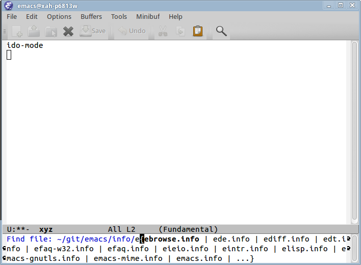

From [Xah Emacs Blog](https://wilkesley.org/~ian/xah/emacs/emacs_iswitch_vs_ido.html)

## History of code completion in Emacs: [IDO vertical](https://github.com/creichert/ido-vertical-mode.el)

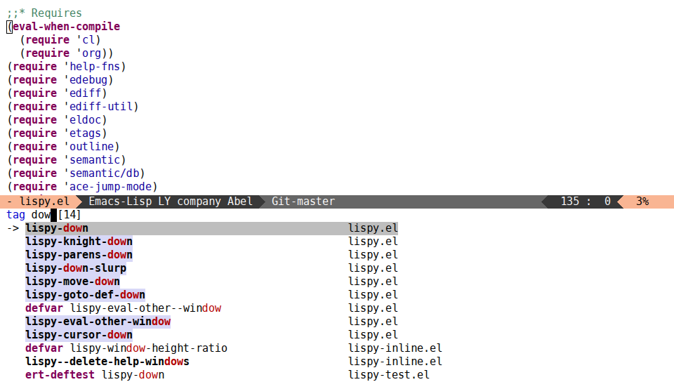

From [oremacs](https://oremacs.com/2015/02/09/ido-vertical/)

## History of code completion in Emacs: [HELM](https://github.com/emacs-helm/helm)

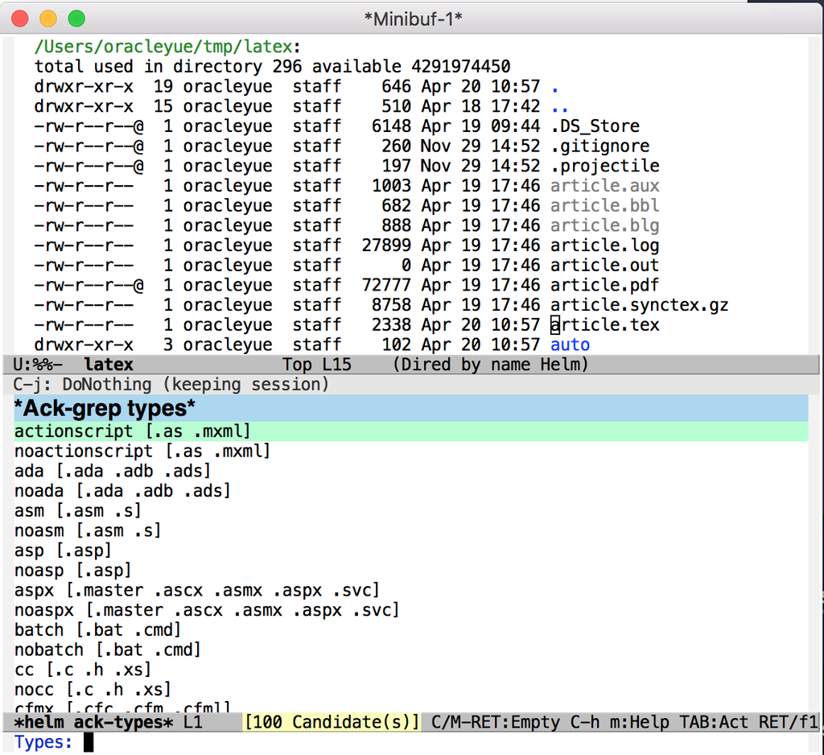

From [oracleyue](https://github.com/emacs-helm/helm/issues/2023)

## History of code completion in Emacs: [Ivy](https://github.com/abo-abo/swiper)

*With optional Counsel & Swiper*

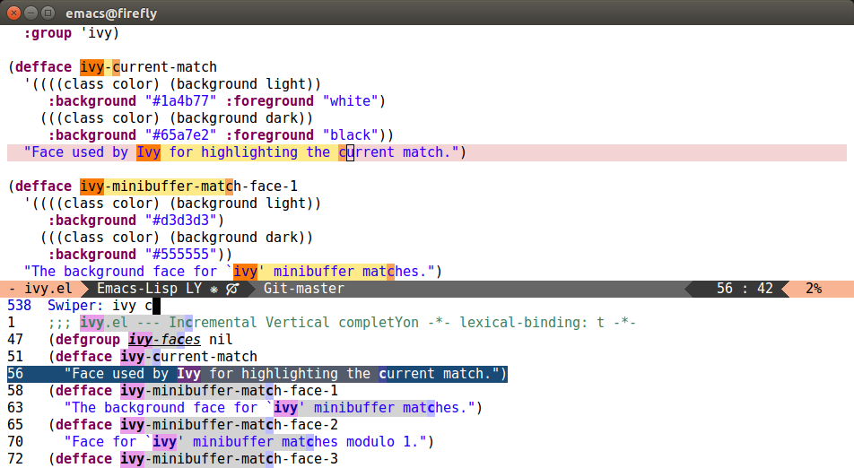

From abo-abo/swiper

## New framework

*External packages*  
*Use default Emacs functions (less code)*  
**Faster**, flexible, customizable with discrete units

## Packages

### Minibuffer

- vertico frontend completion UI
- orderless backend completion style
- consult backend completion functions
- [marginalia](https://github.com/minad/marginalia/) annotations
- [embark](https://github.com/oantolin/embark/) actions on completion buffer

### In buffer

- corfu frontend completion UI
- orderless backend completion style
- cape backend completion functions
- *eglot backend LSP client*

## Compared to previous frameworks

- Integrates beautifully with internal Emacs functions
- Easy jump back & forth between buffer and completion buffer
- Much faster than HELM
- Lightning fast previews with auto-closing buffers
- Easy customization

## Example configuration

*Vertico (frontend for completion in minibuffer)*

```
(use-package vertico
  :init
  (vertico-mode 1)
  (vertico-multiform-mode 1)
  :config
  (setq vertico-multiform-commands
    '((consult-line buffer)
      (consult-line-thing-at-point buffer)
      (consult-recent-file buffer)
      (consult-mode-command buffer)
      (consult-complex-command buffer)
      (embark-bindings buffer)
      (consult-locate buffer)
      (consult-project-buffer buffer)
      (consult-ripgrep buffer)
      (consult-fd buffer)))
  :bind (:map vertico-map
          ("C-k" . kill-whole-line)
          ("C-u" . kill-whole-line)
          ("C-o" . vertico-next-group)
          ("<tab>" . minibuffer-complete)
          ("M-<return>" . minibuffer-force-complete-and-exit)))

;; save search history
(use-package savehist
  :init
  (savehist-mode 1))
```

## Language Server Protocol client

*Built-in since version 29*

[Eglot](https://github.com/joaotavora/eglot) (Emacs Polyglot) allows to connect to [a programming language server](https://github.com/joaotavora/eglot?tab=readme-ov-file#connecting-to-a-server)

### Example: Julia

Need to install an [LSP for Julia](https://github.com/non-Jedi/eglot-jl):

```
(straight-use-package 'eglot-jl)
```

Then run `eglot-jl-init`

Now `eglot` in a Julia buffer connects to the server

## ❤ to all Emacs developers and maintainers

In particular,

developers, maintainers, and contributors to Emacs core,  
developers and maintainers to some of the mentioned packages:  
[Daniel Mendler](https://github.com/minad)  
[Omar Antolín Camarena](https://github.com/oantolin)  
[João Távora](https://github.com/joaotavora)  
[Robb Enzmann](https://github.com/renzmann)  
[John Wiegley](https://github.com/jwiegley)  
[Adam B](https://github.com/non-Jedi)  
and all their contributors

[figure not shown]

Back to webinar page